# Exercise 7

1/21/2021

## A presentation of random statistics and math stuff

## The model used in my thesis project

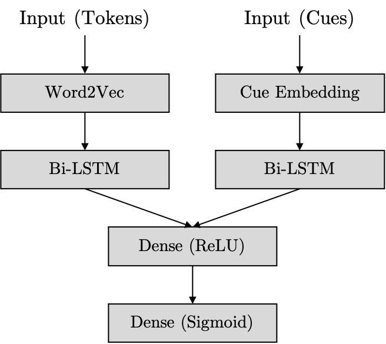

## The famous Iris data set

|  | Sepal.Length | Sepal.Width | Petal.Length | Petal.Width | Species |
| --- | --- | --- | --- | --- | --- |
| 1 | 5.1 | 3.5 | 1.4 | 0.2 | setosa |
| 2 | 4.9 | 3 | 1.4 | 0.2 | setosa |
| 3 | 4.7 | 3.2 | 1.3 | 0.2 | setosa |
| 4 | 4.6 | 3.1 | 1.5 | 0.2 | setosa |
| 5 | 5 | 3.6 | 1.4 | 0.2 | setosa |
| 6 | 5.4 | 3.9 | 1.7 | 0.4 | setosa |
| 7 | 4.6 | 3.4 | 1.4 | 0.3 | setosa |
| 8 | 5 | 3.4 | 1.5 | 0.2 | setosa |
| 9 | 4.4 | 2.9 | 1.4 | 0.2 | setosa |
| 10 | 4.9 | 3.1 | 1.5 | 0.1 | setosa |

[output cut: 140 more lines]

## Differential Calculus

The function \(x \mapsto \frac{1}{16}x^4\) and its first 4 derivatives

[interactive chart not shown]

## A random piece from my Thesis Report

The data set consists of 14462 sentences with their negation cue and negation scope annotations. After standardization and tokenization, a sentence \(s_i\) is represented by a vector \(\mathbf{x}_i = (x_{1_i}~\cdots~x_{t_i}~\cdots~x_{n_i})^{\prime}\) of tokens, where \(i\) is the sentence index, \(n_i\) is the number of tokens in the sentence and \(t = 1,2, \dots, n\) is its token index. In the current study, hyphenated words were considered as one token, and commas and periods were excluded. This resulted in 17602 unique tokens. Let the vocabulary \(X = \{x_1,\dots, x_{17602}\}\) be the ordered set of tokens and \(V=\{1,\dots,|X|\}\) the set of their indices, so that every token is associated with a unique vocabulary index in V. Then, a token vector \(\mathbf{x}_i\) can be vectorized by mapping each \(x_{t_i}\) to its vocabulary index \(v_{t_i} \in V\), obtaining a sequence \(\mathbf{v}_i = (v_{1_i}~\cdots~v_{n_i})^{\prime}\) for each sentence \(s_i\).

Each sentence \(s_i\) is associated with a negation cue vector and a negation scope vector. The cue vector \(\mathbf{c}_i = (c_{1_i}~\cdots~c_{n_i})^{\prime} \in \{0,1\}^{n_i}\) indicates which tokens are annotated as a cue token, so \(c_{t_i}=1\) if the \(t\)-th token from the corresponding token vector \(\mathbf{x}_i\) is a negation cue and \(c_{t_i}=0\) otherwise. The scope vector of sentence \(s_i\) is defined as \(\mathbf{y}_i=(y_{1_i}~\cdots~y_{n_i})^{\prime} \in \{0,1\}^{n_i}\), where \(y_{t_i}=1\) if the \(t\)-th token from \(\mathbf{x}_i\) is annotated as a negation cue or affected by it, and \(y_{t_i}=0\) otherwise. This vector is referred to as the label vector.

## Surface area of a sphere with integral calculus

\[\begin{aligned}\int_{\mathcal{S}} \mathrm{d}S &= \int_{0}^{\pi} \int_{0}^{2\pi} r^2 \sin\varphi ~\mathrm{d}\theta\mathrm{d}\varphi \\ &= r^2 \int_{0}^{\pi} \sin\varphi \left(\int_{0}^{2\pi} \mathrm{d}\theta \right) \mathrm{d}\varphi \\ &= 2\pi r^2 \int_{0}^{\pi} \sin\varphi ~\mathrm{d}\varphi \\ &= 2\pi r^2 (-\cos\varphi) \Big|_0^\pi \\ &= 4\pi r^2. \end{aligned}\]

## LSTM

A Long Short-Term Memory (LSTM) Neural Network is a type of Recurrent Neural Network that is capable of retaining information from longer input sequences (Hochreiter and Schmidhuber 1997)

## Simulation of the Monty Hall problem

```r
switch <- FALSE
prices <- rep(NA,10000)

for (i in 1:10000){
  carsWon <- 0
  doors  <- sample(c("car", "goat", "goat"), size=3, replace=F)
  choice <- sample(1:3, size=1)

  if (doors[choice] == "car"){
    show <- sample((1:3)[-choice], size=1)
  } else if (doors[choice] == "goat"){
    car  <- which(doors == "car")
    show <- (1:3)[-c(choice, car)]
  }

  if (switch == TRUE) {
    price <- doors[-c(choice, show)]
  } else price <- doors[choice]

  prices[i] <- price
}

mean(prices == "car")
```

[output not shown]

## References

Hochreiter, Sepp, and Jürgen Schmidhuber. 1997. “Long Short-Term Memory.” *Neural Computation* 9 (8). MIT Press: 1735–80.